# DDS Project 1: Beers and Breweries

Stephanie Duarte and Catherine Ticzon

2023-06-19

## Introduction

The purpose of this document is to share the results and code for an initial data exploration analysis of the following data sets: beers and breweries.

Below are the questions addressed in this file:

1. How many breweries are in each state?
2. Merge beer data with the breweries data. Print the first 6 observations and the last six observations to check the merged file.
3. Address the missing values in each column.
4. Compute the median alcohol content and international bitterness unit for each state. Plot a bar chart to compare.
5. Which state has the maximum alcoholic (ABV) beer? Which state has the most bitter (IBU) beer?
6. Comment on the summary statistics and distribution of the ABV variable.
7. Is there an apparent relationship between the bitterness of the beer and its alcoholic content? Draw a scatter plot.
8. Budweiser would also like to investigate the difference with respect to IBU and ABV between IPAs (India Pale Ales) and other types of Ale (any beer with “Ale” in its name other than IPA).

```r
# Load data sets
beers <- read.csv("C:\\Users\\48103982\\Documents\\MSDS\\6306 Doing Data Science\\Project 1\\Beers.csv", header=TRUE)
breweries <- read.csv("C:\\Users\\48103982\\Documents\\MSDS\\6306 Doing Data Science\\Project 1\\Breweries.csv", header=TRUE)

# Remove white space from data frame
breweries2 <- breweries %>% mutate(across(where(is.character), str_trim))

# Create lookup to add full state name
lookup <- data.frame(abb = state.abb, State = state.name)
colnames(breweries2)[4] = "abb"
breweriesClean <- merge(breweries2, lookup, by.x = "abb", by.y = "abb", all.x = TRUE, all.y = FALSE)
```

## 1. How many breweries are in each state?

The code used to answer this questions first groups the breweries by state and that was stored as its own variable. A bar graph and a heatmap are used to visualize the information. The variable that stores the states and the corresponding number of breweries is printed out to see a list of all values.

**Summary:**

- Total of 558 breweries across the U.S.
  - 3 states with 30 or more breweries
  - 7 states with 20-29 breweries
  - 9 states with 10-19 breweries
  - 31 states with 10 breweries or less
- Colorado has the most number of breweries (47)

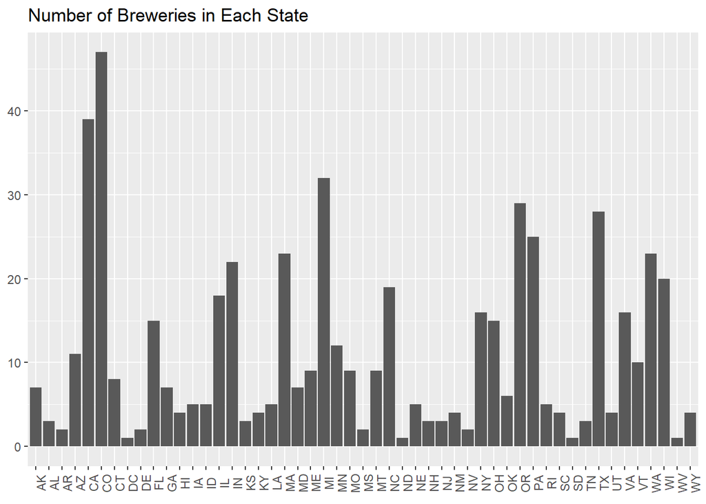

```r
numberOfBreweries <- count(group_by(breweriesClean, State))
# write_csv(numberOfBreweries, path="C:\\Users\\48103982\\Documents\\MSDS\\6306 Doing Data Science\\Project 1\\numberOfBreweries.csv")

# Create a plot with number of breweries by state
ggplot(data=breweries, mapping = aes(x=State)) +
  geom_bar() +
  theme(axis.text.x = element_text(angle=90),
        axis.title.x = element_blank(),
        axis.title.y = element_blank()) +
  labs(title="Number of Breweries in Each State")
```

```r
# Print out values
print(numberOfBreweries, n=51)
```

```
## # A tibble: 51 × 2
## # Groups:   State [51]
##    State              n
##    <chr>          <int>
##  1 Alabama            3
##  2 Alaska             7
##  3 Arizona           11
##  4 Arkansas           2
##  5 California        39
##  6 Colorado          47
##  7 Connecticut        8
##  8 Delaware           2
##  9 Florida           15
## 10 Georgia            7
## 11 Hawaii             4
```

[output cut: 40 more lines]

```r
sum(numberOfBreweries$n)
```

```
## [1] 558
```

### Create a heatmap with data

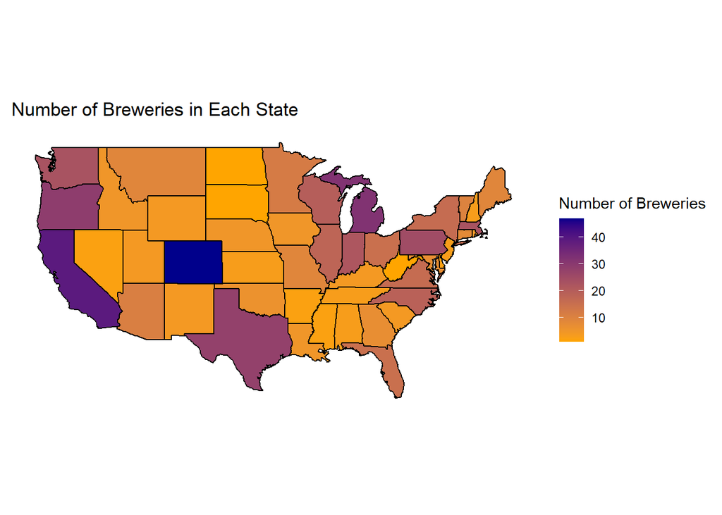

```r
numberOfBreweries$region <- tolower(numberOfBreweries$State)
states <- map_data("state")
map.df <- merge(states,numberOfBreweries, by="region", all.x=T)
map.df <- map.df[order(map.df$order),]

ggplot(map.df, aes(x=long,y=lat,group=group))+
  geom_polygon(aes(fill=n)) +
  geom_path() +
  scale_fill_continuous(low = "orange",
            high = "darkblue",
            na.value = "grey50") +
  ggtitle("Number of Breweries in Each State ") +
  theme(axis.text.x = element_blank(),
        axis.text.y = element_blank(),
        axis.title.x = element_blank(),
        axis.title.y = element_blank(),
        panel.border = element_blank(),
        panel.grid.major = element_blank(),
        panel.grid.minor = element_blank(),
        panel.background = element_blank(),
        axis.ticks = element_blank()) +
   labs(fill = "Number of Breweries") +
coord_map()
```

## 2. Merge beer data with the breweries data. Print the first 6 observations and the last six observations to check the merged file.

Merging the beer and breweries data sets into one file is necessary to answer the remaining questions. Data sets were merged by brewery ID numbers.

```r
# Rename brewery ID column so they match in both data sets before joining
colnames(breweriesClean)[2] <- "Brewery_id"

bb <- full_join(beers, breweriesClean, by = "Brewery_id") %>%
  rename("Beer" = "Name.x",
         "Brewery" = "Name.y")

bb$ABV = as.numeric(bb$ABV)

head(bb, 6)
```

```
##                  Beer Beer_ID   ABV IBU Brewery_id
## 1            Pub Beer    1436 0.050  NA        409
## 2         Devil's Cup    2265 0.066  NA        178
## 3 Rise of the Phoenix    2264 0.071  NA        178
## 4            Sinister    2263 0.090  NA        178
## 5       Sex and Candy    2262 0.075  NA        178
## 6        Black Exodus    2261 0.077  NA        178
##                            Style Ounces abb                   Brewery City
## 1            American Pale Lager     12  OR 10 Barrel Brewing Company Bend
## 2        American Pale Ale (APA)     12  IN       18th Street Brewery Gary
## 3                   American IPA     12  IN       18th Street Brewery Gary
## 4 American Double / Imperial IPA     12  IN       18th Street Brewery Gary
## 5                   American IPA     12  IN       18th Street Brewery Gary
## 6                  Oatmeal Stout     12  IN       18th Street Brewery Gary
##     State
## 1  Oregon
## 2 Indiana
## 3 Indiana
## 4 Indiana
## 5 Indiana
## 6 Indiana
```

```r
tail(bb, 6)
```

```
##                             Beer Beer_ID   ABV IBU Brewery_id
## 2405 Rocky Mountain Oyster Stout    1035 0.075  NA        425
## 2406                   Belgorado     928 0.067  45        425
## 2407               Rail Yard Ale     807 0.052  NA        425
## 2408             B3K Black Lager     620 0.055  NA        425
## 2409         Silverback Pale Ale     145 0.055  40        425
## 2410        Rail Yard Ale (2009)      84 0.052  NA        425
##                         Style Ounces abb                 Brewery   City
## 2405           American Stout     12  CO Wynkoop Brewing Company Denver
## 2406              Belgian IPA     12  CO Wynkoop Brewing Company Denver
## 2407 American Amber / Red Ale     12  CO Wynkoop Brewing Company Denver
## 2408              Schwarzbier     12  CO Wynkoop Brewing Company Denver
## 2409  American Pale Ale (APA)     12  CO Wynkoop Brewing Company Denver
## 2410 American Amber / Red Ale     12  CO Wynkoop Brewing Company Denver
##         State
## 2405 Colorado
## 2406 Colorado
## 2407 Colorado
## 2408 Colorado
## 2409 Colorado
## 2410 Colorado
```

## 3. Address the missing values in each column

The code used to answer this question first identifies all instances of missing data. Then, code was written to summarize the two methods used to address the missing data. A barplot and boxplots are used to visualize the data.

**Summary:**

Two methods used to address the missing data:

While there are slight differences (less than 0.3%) between the median, mean, and maximum, the largest resulting difference between the two methods was related to the minimum. By eliminating the missing data, the minimum is 2.7; by replacing the missing data with the average, the minimum is 0.1%.

```r
summary(bb)
```

```
##      Beer              Beer_ID            ABV               IBU
##  Length:2410        Min.   :   1.0   Min.   :0.00100   Min.   :  4.00
##  Class :character   1st Qu.: 808.2   1st Qu.:0.05000   1st Qu.: 21.00
##  Mode  :character   Median :1453.5   Median :0.05600   Median : 35.00
##                     Mean   :1431.1   Mean   :0.05977   Mean   : 42.71
##                     3rd Qu.:2075.8   3rd Qu.:0.06700   3rd Qu.: 64.00
##                     Max.   :2692.0   Max.   :0.12800   Max.   :138.00
##                                      NA's   :62        NA's   :1005
##    Brewery_id       Style               Ounces          abb
##  Min.   :  1.0   Length:2410        Min.   : 8.40   Length:2410
##  1st Qu.: 94.0   Class :character   1st Qu.:12.00   Class :character
##  Median :206.0   Mode  :character   Median :12.00   Mode  :character
##  Mean   :232.7                      Mean   :13.59
##  3rd Qu.:367.0                      3rd Qu.:16.00
##  Max.   :558.0                      Max.   :32.00
##
##    Brewery              City              State
##  Length:2410        Length:2410        Length:2410
##  Class :character   Class :character   Class :character
##  Mode  :character   Mode  :character   Mode  :character
##
##
##
##
```

```r
# Barplot of missing data
sum(is.na(bb))
```

```
## [1] 1075
```

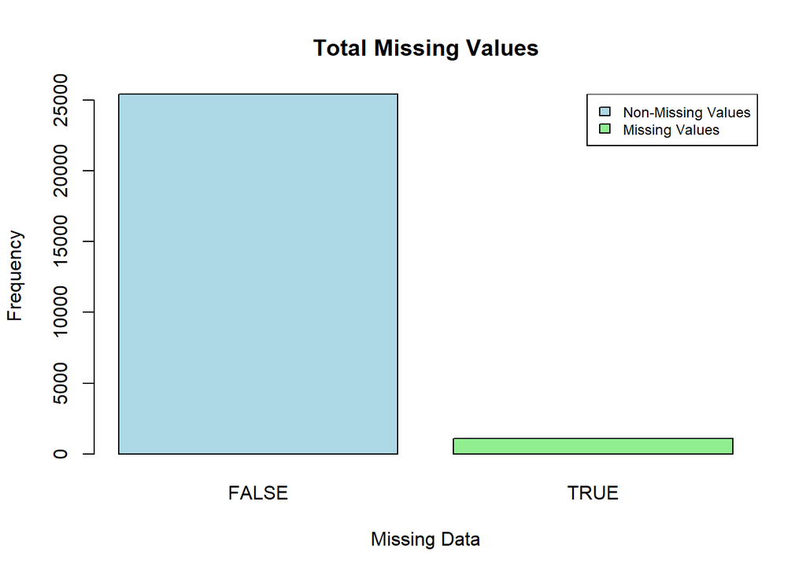

```r
df<- data.frame(table(is.na(bb)))

barplot(df$Freq , main = "Total Missing Values",
 xlab = "Missing Data", ylab = "Frequency",
 names.arg = c("FALSE","TRUE"),
 col = c("lightblue","lightgreen"))
legend("topright",
     c("Non-Missing Values","Missing Values"),
     fill = c("lightblue","lightgreen"), cex = 0.75)
```

```r
# Method 1: Eliminate missing data
completed_beer <- bb[complete.cases(bb),] #bb with only complete records
dim(completed_beer)
```

```
## [1] 1401   11
```

```r
# Create Boxplot
summary(completed_beer$ABV)
```

```
##    Min. 1st Qu.  Median    Mean 3rd Qu.    Max.
##  0.0270  0.0500  0.0570  0.0599  0.0680  0.1250
```

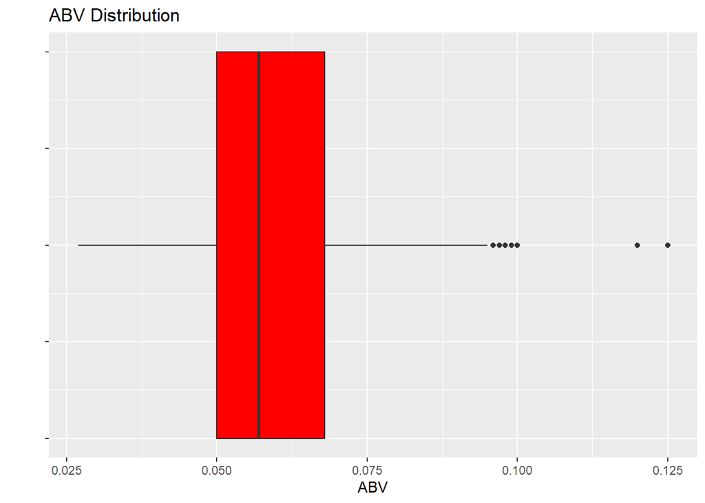

```r
ggplot(data = completed_beer, mapping = aes(x = ABV)) +
  geom_boxplot(fill = "red", width=.1) +
  labs(x = "ABV", title = "ABV Distribution") +
  theme(axis.text.y=element_text(colour="white"))
```

```r
#Method 2: replace missing data with average
average_beer <- bb
averageABV <- mean(average_beer$ABV, na.rm = TRUE)
averageIBU <- mean(average_beer$IBU, na.rm = TRUE)
average_beer$IBU[is.na(average_beer$IBU)]<- averageIBU
average_beer$ABV[is.na(average_beer$ABV)]<- averageABV
colSums(is.na(average_beer))
```

```
##       Beer    Beer_ID        ABV        IBU Brewery_id      Style     Ounces
##          0          0          0          0          0          0          0
##        abb    Brewery       City      State
##          0          0          0          8
```

```r
#create Boxplot
summary(average_beer$ABV)
```

```
##    Min. 1st Qu.  Median    Mean 3rd Qu.    Max.
## 0.00100 0.05000 0.05700 0.05977 0.06700 0.12800
```

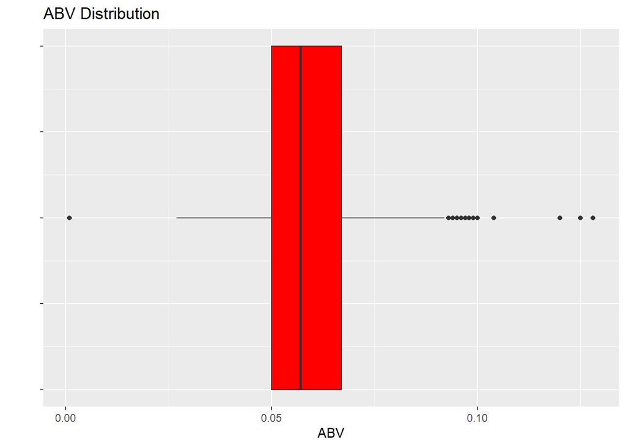

```r
ggplot(data = average_beer, mapping = aes(x = ABV)) +
  geom_boxplot(fill = "red", width=.1) +
  labs(x = "ABV", title = "ABV Distribution") +
  theme(axis.text.y=element_text(colour="white"))
```

## 4. Compute the median alcohol content and international bitterness unit for each state. Plot a bar chart to compare.

The code used to answer this question first creates a variable that stores the median ABV for each state. Then, a bar graph is created to visualize the information. The same is done for the median IBU.

**Summary:**

Alcohol content (ABV):

- Mean of all state ABV medians: 5.6%
- Kentucky has the highest ABV median: 6.25%
- Utah has the lowest ABV median: 4%

Bitterness (IBU):

- Mean of all state IBU medians: 36.98
- Maine has the highest IBU median: 61
- Wisconsin has the lowest IBU median: 19
- South Dakota does not have IBU data for its beers

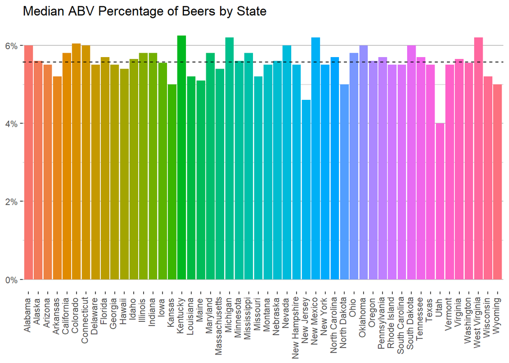

```r
# Calculate median ABV by state, remove NA row in State
medABV <- bb %>%
  group_by(State) %>%
  filter(!is.na(ABV)) %>%
  filter(!is.na(State)) %>%
  summarize(medianABV = median(ABV))

mean_median_abv <- mean(medABV$medianABV)

# Plot median ABV

ggplot(data= medABV, mapping = aes(x=State, y=medianABV, fill=State)) +
  geom_col() +
  theme(axis.text.x = element_text(angle=90,hjust=0.95,vjust=0.2),
        axis.title.x = element_blank(),
        axis.title.y = element_blank(),
        legend.position = "none",
        panel.grid.major.y = element_line(color= "grey"),
        panel.grid.major.x = element_blank(),
        panel.grid.minor.x = element_blank(),
        panel.grid.minor.y = element_line(color="grey"),
        panel.background = element_blank()) +
  scale_y_continuous(labels = scales::percent_format(accuracy = 1)) +
  #expand_limits(y=c(0.03, 0.08)) +
  labs(title="Median ABV Percentage of Beers by State") +
  geom_hline(yintercept = mean_median_abv, color = "black", linetype="dashed")
```

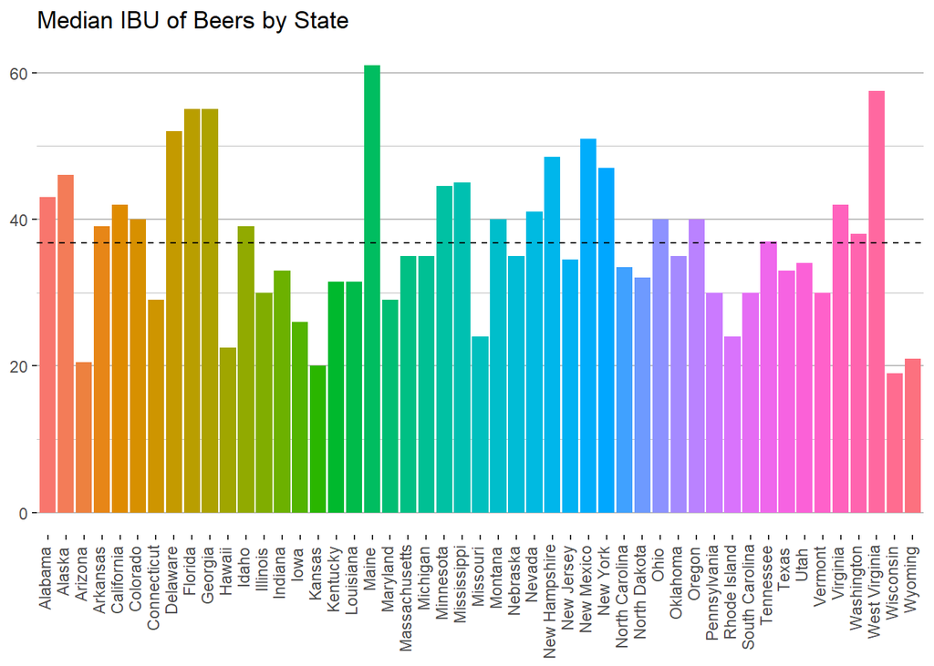

```r
# Calculate median IBU by state
medIBU <- bb %>%
  group_by(State) %>%
  filter(!is.na(IBU)) %>%
  filter(!is.na(State)) %>%
  summarize(medianIBU = median(IBU))

# Where is South Dakota?
# bb %>% filter(abb=="SD")
# Beers in SD do not have corresponding IBU
mean_median_IBU <- mean(medIBU$medianIBU)

# Plot median IBU by state

ggplot(data= medIBU, mapping = aes(x=State, y=medianIBU, fill=State)) +
  geom_col() +
  theme(axis.text.x = element_text(angle=90,hjust=0.95,vjust=0.2),
        axis.title.x = element_blank(),
        axis.title.y = element_blank(),
        legend.position = "none",
        panel.grid.major.y = element_line(color="grey"),
        panel.grid.major.x = element_blank(),
        panel.grid.minor.x = element_blank(),
        panel.grid.minor.y = element_line(color="grey"),
        panel.background = element_blank()) +
  labs(title="Median IBU of Beers by State") +
  geom_hline(yintercept = mean_median_IBU, color = "black", linetype="dashed")
```

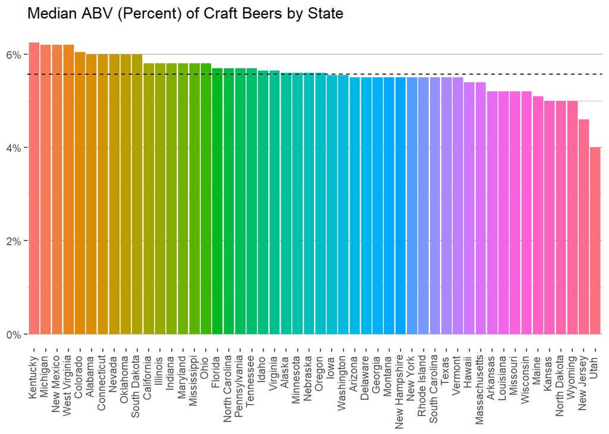

```r
# Reorder the levels of the State variable based on median ABV
medABV$State <- factor(medABV$State, levels = medABV$State[order(medABV$medianABV,
                                                                 decreasing = TRUE)])
medABV50 <- medABV[-c(51), ] # Remove row where State is NA

# Create the median ABV plot with ordered bars
ggplot(medABV50, aes(x = State, y = medianABV, fill = State)) +
  geom_bar(stat = "identity") +
  labs(title = "Median ABV (Percent) of Craft Beers by State") +
  theme(axis.text.x = element_text(angle = 90, hjust = .95, vjust = 0.2),
        axis.title.x = element_blank(),
        axis.title.y = element_blank(),
        legend.position = "none",
        panel.grid.major.y = element_line(color="grey"),
        panel.grid.major.x = element_blank(),
        panel.grid.minor.x = element_blank(),
        panel.grid.minor.y = element_line(color="grey"),
        panel.background = element_blank()) +
  scale_y_continuous(labels = scales::percent_format(accuracy = 1)) +
  geom_hline(yintercept = mean_median_abv, color = "black", linetype="dashed")
```

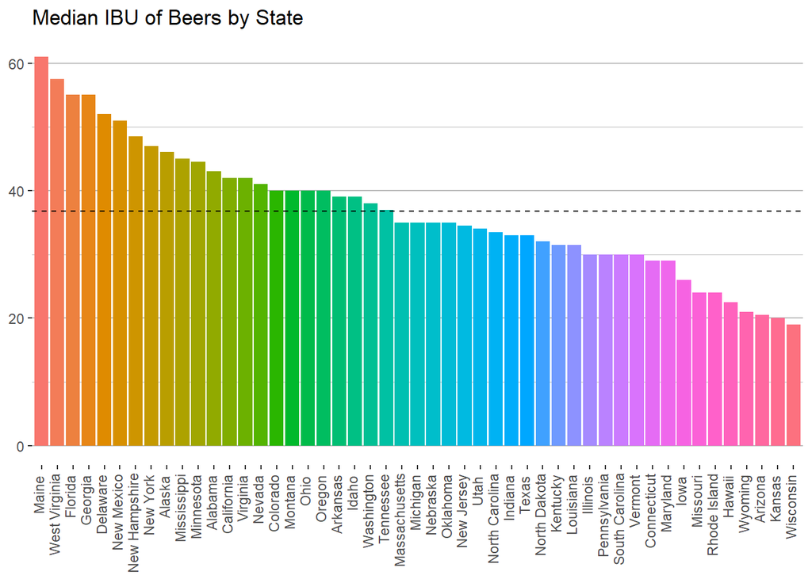

```r
# Reorder the levels of the State variable based on median IBU
medIBU$State <- factor(medIBU$State, levels = medIBU$State[order(medIBU$medianIBU,
                                                                 decreasing = TRUE)])

# South Dakota is not on here because beers in SD do not have corresponding IBU

ggplot(data= medIBU, mapping = aes(x=State, y=medianIBU, fill=State)) +
  geom_col() +
  theme(axis.text.x = element_text(angle=90,hjust=0.95,vjust=0.2),
        axis.title.x = element_blank(),
        axis.title.y = element_blank(),
        legend.position = "none",
        panel.grid.major.y = element_line(color="grey"),
        panel.grid.major.x = element_blank(),
        panel.grid.minor.x = element_blank(),
        panel.grid.minor.y = element_line(color="grey"),
        panel.background = element_blank()) +
  labs(title="Median IBU of Beers by State") +
  geom_hline(yintercept = mean_median_IBU, color = "black", linetype="dashed")
```

## 5. Which state has the maximum alcoholic (ABV) beer? Which state has the most bitter (IBU) beer?

The code used to answer this question simply determines which state has the maximum value in the ABV and IBU column.

**Summary:**

- Highest ABV: Lee Hill Series Ale (12.8%) made by Upslope Brewing Company – Colorado
- Most bitter: Bitter Bitch Imperial IPA (138) made by Astoria Brewing Company – Oregon

```r
# Find the state with the maximum alcoholic (IBU) beer
state_with_max_IBU <- bb[which.max(bb$IBU), "State"]
bb[which.max(bb$IBU),]
```

```
##                          Beer Beer_ID   ABV IBU Brewery_id
## 148 Bitter Bitch Imperial IPA     980 0.082 138        375
##                              Style Ounces abb                 Brewery    City
## 148 American Double / Imperial IPA     12  OR Astoria Brewing Company Astoria
##      State
## 148 Oregon
```

```r
# Find the state with the maximum alcoholic (ABV) beer
state_with_max_abv <- bb[which.max(bb$ABV), "State"]
bb[which.max(bb$ABV),]
```

```
##                                                      Beer Beer_ID   ABV IBU
## 2279 Lee Hill Series Vol. 5 - Belgian Style Quadrupel Ale    2565 0.128  NA
##      Brewery_id            Style Ounces abb                 Brewery    City
## 2279         52 Quadrupel (Quad)   19.2  CO Upslope Brewing Company Boulder
##         State
## 2279 Colorado
```

## 6. Comment on the summary statistics and distribution of the ABV variable.

The code used to answer this question first summarizes the ABV column and then uses a boxplot to visualize the spread of values. A histogram is also included and shows right-skewedness.

**Summary:**

- A boxplot is used to show the spread of the ABV variable
  - Minimum is 0.1% (a beer from California)
  - Maximum is 12.8% (a beer from Colorado)
  - Mean is 5.977%

```r
# Summary statistics of ABV variable
bb$ABVpercent <- bb$ABV*100
summary(bb$ABVpercent)
```

```
##    Min. 1st Qu.  Median    Mean 3rd Qu.    Max.    NA's
##   0.100   5.000   5.600   5.977   6.700  12.800      62
```

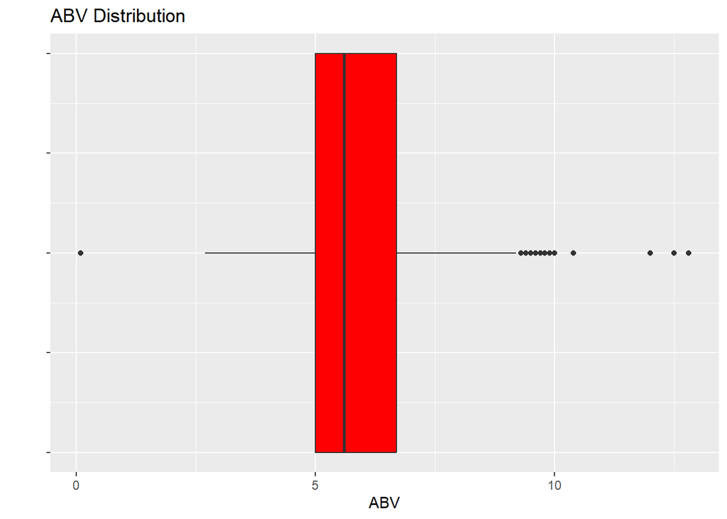

```r
# Create box plot
ggplot(data = bb, mapping = aes(x = ABV * 100)) +
  geom_boxplot(fill = "red", width=.1) +
  labs(x = "ABV", title = "ABV Distribution") +
  theme(axis.text.y=element_text(colour="white"))
```

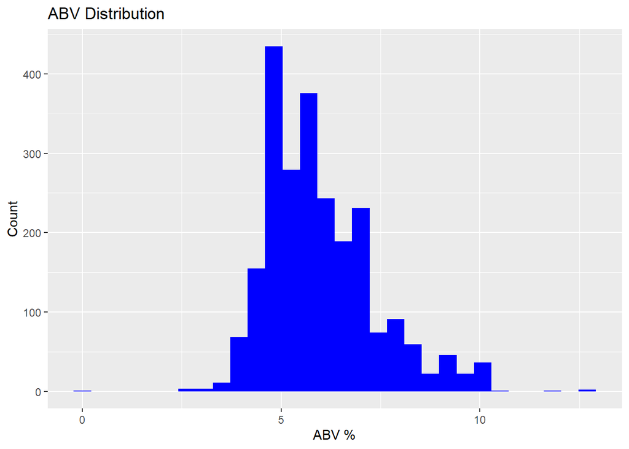

```r
# Distribution of ABV variable
ggplot(data = bb, mapping = aes(x = ABV * 100)) +
  geom_histogram(fill= "blue", width=.1) +
  labs(x = "ABV %",y = "Count", title = "ABV Distribution")
```

## 7. Is there an apparent relationship between the bitterness of the beer and its alcoholic content? Draw a scatter plot. Make your best judgment of a relationship and EXPLAIN your answer.

The code used to answer this question creates a scatterpolt where the x-axis is IBU and the y-axis is ABV.

**Summary:**

- Visually, it looks like there is some positive relationship between IBU and ABV
  - As IBU increases, ABV tends to also increase

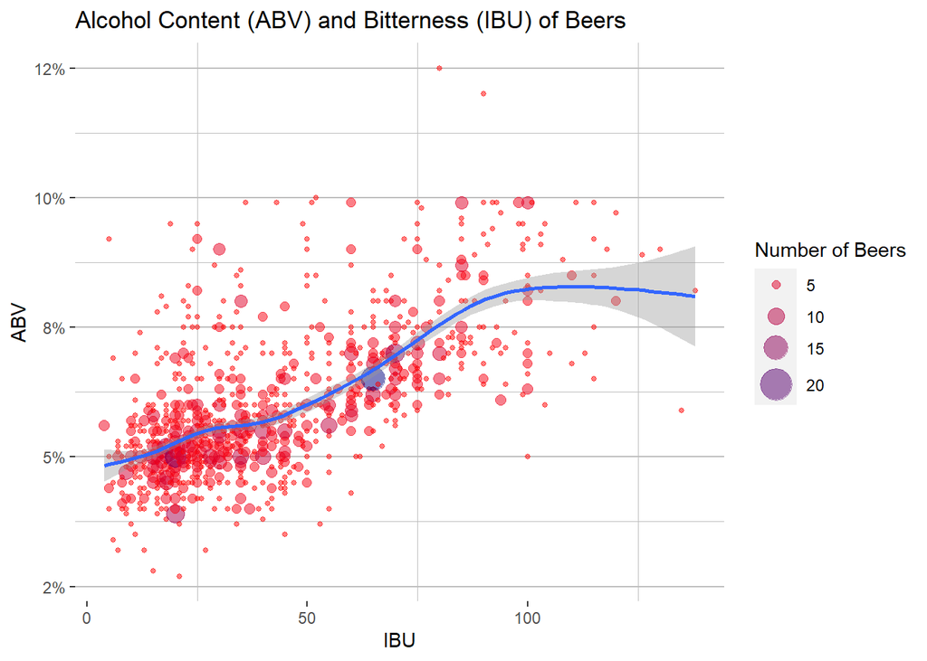

```r
ggplot(data = beers, mapping = aes(x=IBU, y=ABV)) +
  geom_count(aes(color = ..n..), alpha=.5) +
  geom_smooth() +
  scale_y_continuous(labels = scales::percent_format(accuracy = 1)) +
    theme(panel.grid.major.y = element_line(color="grey"),
        panel.grid.major.x = element_blank(),
        panel.grid.minor.x = element_line(color="grey"),
        panel.grid.minor.y = element_line(color="grey"),
        panel.background = element_blank()) +
  scale_color_gradient(low = "red", high ="navy") +
  labs(title="Alcohol Content (ABV) and Bitterness (IBU) of Beers",
       colour="Number of Beers") +
   guides(color = guide_legend(override.aes = list(size = c(2, 4, 6, 8))),
          size = "none")
```

## 8. Budweiser would also like to investigate the difference with respect to IBU and ABV between IPAs (India Pale Ales) and other types of Ale (any beer with “Ale” in its name other than IPA).

#### You decide to use KNN classification to investigate this relationship. Provide statistical evidence one way or the other. You can of course assume your audience is comfortable with percentages … KNN is very easy to understand conceptually. In addition, while you have decided to use KNN to investigate this relationship (KNN is required) you may also feel free to supplement your response to this question with any other methods or techniques you have learned. Creativity and alternative solutions are always encouraged.

Transform data to analyze in Test 1:

```r
IPA <- bb %>%
  filter(str_detect(Style, "IPA"))

ale <- bb %>%
  filter(str_detect(Style,"Ale"))

# Some IPAs are still in the ale variable; need to remove
other_ales <- ale[!str_detect(ale$Style, "\\bIPA\\b"), ]

# Dataset that includes both IPAs and other ales only
allAles <- bb[str_detect(bb$Style, "\\bIPA\\b") | str_detect(bb$Style, "\\bAle\\b"), ]

allAles_complete <- allAles[complete.cases(allAles$ABVpercent), ]

# Create a column Is_IPA
allAles_complete$Is_IPA <- ifelse(str_detect(allAles_complete$Style, "\\bIPA\\b"), "IPA", "Other Ale")
```

#### Test 1: If a beer has an ABV of 5.6% (median ABV across all states), what are the chances that it is an IPA?

The code used to explore this question first creates training and split set to be used in the knn model. Then, knn models are run.

**Summary:**

- Created a dataset that includes ales **only** (both IPAs and other ales)
  - Created a training set and a test set with an 80/20 split
- Using knn where k=3 and k=5, there is less than a 6% chance that the beer is an IPA (94.11% probability that it is another ale)

```r
set.seed(6)
splitPerc = .8

# Split into training and test sets
trainInd = sample(1:dim(allAles_complete)[1],round(splitPerc * dim(allAles_complete)[1]))
allAlesTrain = allAles_complete[trainInd,]
allAlesTest = allAles_complete[-trainInd,]

abvTest5 <- data.frame(ABVpercent = 5.6)

knn(allAlesTrain[,"ABVpercent"], abvTest5, allAlesTrain$Is_IPA, prob = TRUE, k = 3)
```

```
## [1] Other Ale
## attr(,"prob")
## [1] 0.9411765
## Levels: IPA Other Ale
```

```r
knn(allAlesTrain[,"ABVpercent"], abvTest5, allAlesTrain$Is_IPA, prob = TRUE, k = 5)
```

```
## [1] Other Ale
## attr(,"prob")
## [1] 0.9411765
## Levels: IPA Other Ale
```

#### Test 2: Across all beer styles (IPAs, other ales, and other), which knn model has the most accuracy?

```r
# Classify IPAs and Ales
beertypes = ifelse(str_detect(bb$Style,"IPA")==TRUE,"IPA",ifelse(str_detect(bb$Style,"Ale")==TRUE,"ALE","Other"))
bb$Type <- beertypes
head(bb)
```

```
##                  Beer Beer_ID   ABV IBU Brewery_id
## 1            Pub Beer    1436 0.050  NA        409
## 2         Devil's Cup    2265 0.066  NA        178
## 3 Rise of the Phoenix    2264 0.071  NA        178
## 4            Sinister    2263 0.090  NA        178
## 5       Sex and Candy    2262 0.075  NA        178
## 6        Black Exodus    2261 0.077  NA        178
##                            Style Ounces abb                   Brewery City
## 1            American Pale Lager     12  OR 10 Barrel Brewing Company Bend
## 2        American Pale Ale (APA)     12  IN       18th Street Brewery Gary
## 3                   American IPA     12  IN       18th Street Brewery Gary
## 4 American Double / Imperial IPA     12  IN       18th Street Brewery Gary
## 5                   American IPA     12  IN       18th Street Brewery Gary
## 6                  Oatmeal Stout     12  IN       18th Street Brewery Gary
##     State ABVpercent  Type
## 1  Oregon        5.0 Other
## 2 Indiana        6.6   ALE
## 3 Indiana        7.1   IPA
## 4 Indiana        9.0   IPA
## 5 Indiana        7.5   IPA
## 6 Indiana        7.7 Other
```

```r
# Impute missing values with median
bbimpute <- bb
bbimpute$IBU[is.na(bbimpute$IBU)]<- median(bbimpute$IBU, na.rm = TRUE)
bbimpute$ABV[is.na(bbimpute$ABV)]<- median(bbimpute$ABV, na.rm = TRUE)
bbimpute$ABVpercent[is.na(bbimpute$ABVpercent)]<- median(bbimpute$ABVpercent, na.rm = TRUE)
bbimpute = bbimpute[complete.cases(bbimpute),]

# Create a Data set for ABV, IBU, and Type
btrain = bbimpute %>% select(c("ABV","IBU","Type"))

# Create kNN for k
set.seed(100)
iterations = 100
numks = 10
splitPerc = .70
masterAcc = matrix(nrow = iterations, ncol = numks)
for(j in 1:iterations)
{
  trainIndices = sample(1:dim(btrain)[1],round(splitPerc * dim(btrain)[1]))
  train = btrain[trainIndices,]
  test = btrain[-trainIndices,]
  for(i in 1:numks)
  {
    classifications = knn(train[,c(1,2)],test[,c(1,2)],train$Type, prob = TRUE, k = i)
    table(classifications,test$Type)
    CM = confusionMatrix(table(classifications,test$Type))
    masterAcc[j,i] = CM$overall[1]
  }

}

CM
```

```
## Confusion Matrix and Statistics
##
##
## classifications ALE IPA Other
##           ALE   168  53   140
##           IPA    15  97    22
##           Other  90  29   107
##
## Overall Statistics
##
##                Accuracy : 0.516
##                  95% CI : (0.4788, 0.553)
##     No Information Rate : 0.3786
##     P-Value [Acc > NIR] : 4.968e-14
##
##                   Kappa : 0.2522
##
##  Mcnemar's Test P-Value : 3.120e-07
##
## Statistics by Class:
##
##                      Class: ALE Class: IPA Class: Other
## Sensitivity              0.6154     0.5419       0.3978
## Specificity              0.5692     0.9317       0.7367
## Pos Pred Value           0.4654     0.7239       0.4735
## Neg Pred Value           0.7083     0.8603       0.6727
## Prevalence               0.3786     0.2483       0.3731
## Detection Rate           0.2330     0.1345       0.1484
## Detection Prevalence     0.5007     0.1859       0.3135
## Balanced Accuracy        0.5923     0.7368       0.5672
```

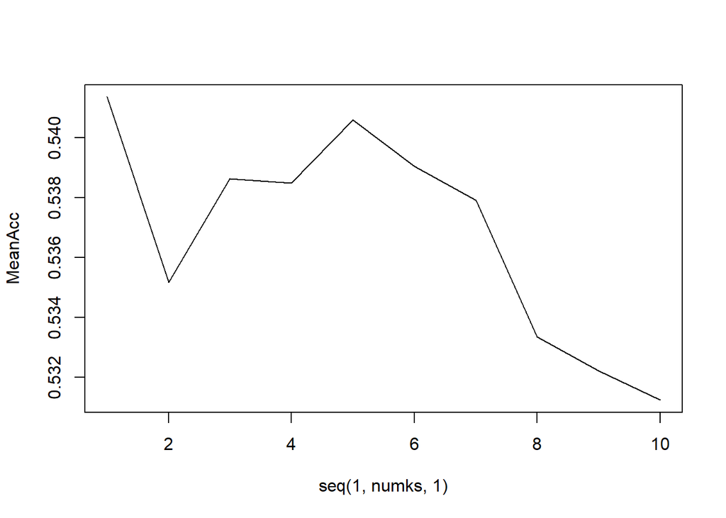

```r
MeanAcc = colMeans(masterAcc)
plot(seq(1,numks,1),MeanAcc, type = "l")
```

```r
which.max(MeanAcc)
```

```
## [1] 1
```

```r
max(MeanAcc)
```

```
## [1] 0.5413731
```

```r
classifications = knn(train[,c(1,2)],test[,c(1,2)],train$Type, prob = TRUE, k = 5)
table(classifications,test$Type)
```

```
##
## classifications ALE IPA Other
##           ALE   165  41   147
##           IPA    15 109    19
##           Other  93  29   103
```

```r
CM = confusionMatrix(table(classifications,test$Type))
CM
```

```
## Confusion Matrix and Statistics
##
##
## classifications ALE IPA Other
##           ALE   165  41   147
##           IPA    15 109    19
##           Other  93  29   103
##
## Overall Statistics
##
##                Accuracy : 0.5229
##                  95% CI : (0.4857, 0.5599)
##     No Information Rate : 0.3786
##     P-Value [Acc > NIR] : 2.736e-15
##
##                   Kappa : 0.2648
##
##  Mcnemar's Test P-Value : 8.234e-06
##
## Statistics by Class:
##
##                      Class: ALE Class: IPA Class: Other
## Sensitivity              0.6044     0.6089       0.3829
## Specificity              0.5804     0.9373       0.7301
## Pos Pred Value           0.4674     0.7622       0.4578
## Neg Pred Value           0.7065     0.8789       0.6653
## Prevalence               0.3786     0.2483       0.3731
## Detection Rate           0.2288     0.1512       0.1429
## Detection Prevalence     0.4896     0.1983       0.3121
## Balanced Accuracy        0.5924     0.7731       0.5565
```

#### General comparisons of the different beers styles (IPAs, other ales, and other).

The code used in this section creates visualizations across the different beer styles: IPAs, other ales, and other beers. The first scatterplot graphs IBU and ABV by beer style; missing values were not included in this plot. The second scatterplot graphs the same information but replaces the missing values with medians. The box plot visualizes the spread of the IBU based on beer type.

**Summary:**

- Generally, IPAs have higher ABV and IBU than other beers
  - Visually there looks to be a steeper positive relationship between ABV and IBU than the other types of beers
- Other beer styles (neither IPA or another ale) generally have less than 50 IBUs

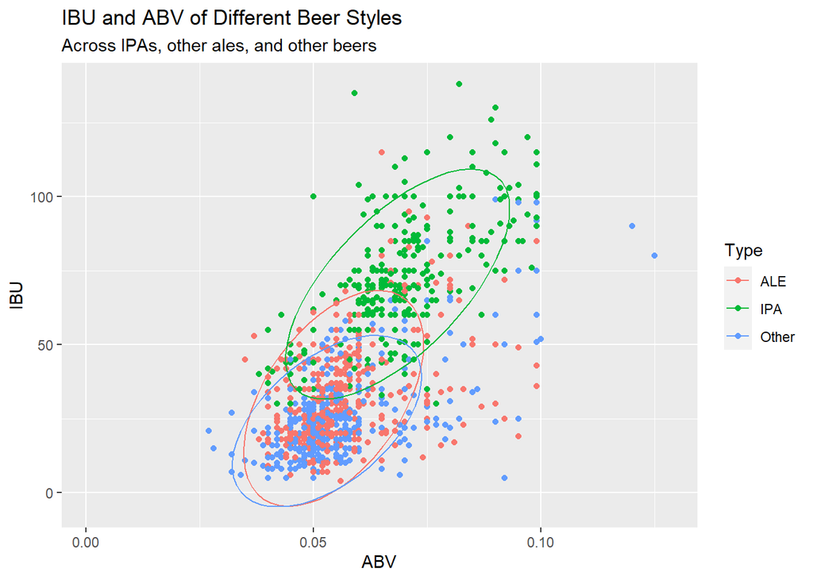

```r
# Create Plot of IBU vs ABV, between different beer types
bb %>% ggplot(aes(x = ABV, y = IBU, color=Type)) +
  geom_point() +
  stat_ellipse() +
  labs(title="IBU and ABV of Different Beer Styles",
       subtitle="Across IPAs, other ales, and other beers")
```

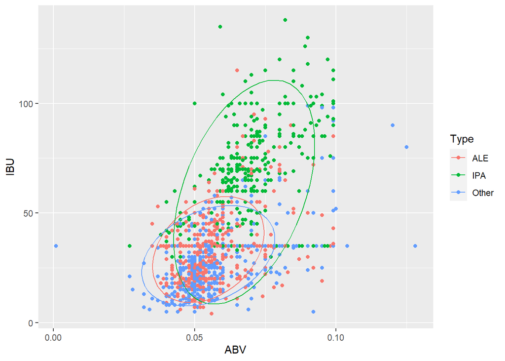

```r
# Impute missing values with median
bbimpute <- bb
bbimpute$IBU[is.na(bbimpute$IBU)]<- median(bbimpute$IBU, na.rm = TRUE)
bbimpute$ABV[is.na(bbimpute$ABV)]<- median(bbimpute$ABV, na.rm = TRUE)
bbimpute$ABVpercent[is.na(bbimpute$ABVpercent)]<- median(bbimpute$ABVpercent, na.rm = TRUE)
bbimpute = bbimpute[complete.cases(bbimpute),]


# Create plot
bbimpute %>% ggplot(aes(x = ABV, y = IBU, color=Type)) + geom_point() + stat_ellipse()
```

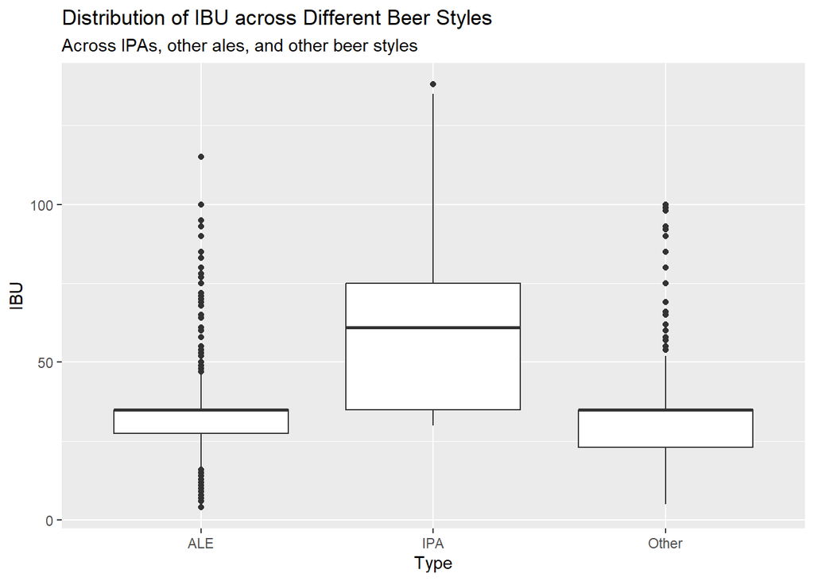

```r
# Boxplot of IBU across different beers
ggplot(data=btrain, mapping=aes(x =Type , y = IBU)) +
  geom_boxplot() +
  labs(title="Distribution of IBU across Different Beer Styles",
       subtitle="Across IPAs, other ales, and other beer styles")
```